# Презентация по лабораторной работе №5

Архиттектура компьютеров и операционные системы

Дауд А.

Российский университет дружбы народов, Москва, Россия

14 марта 2025

# Информация

## Докладчик

# Цель работы

Цель данной работы – настроика рабочей среды с помощью менеджера паролей pass и конфигурации chezmoi.

## Установка и Настройка Pass

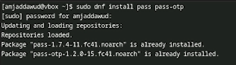

Установка pass pass-otp

## Установка и Настройка Pass

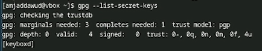

## Установка и Настройка Pass

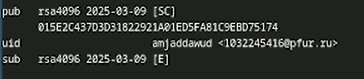

Созданные ключи

## Установка и Настройка Pass

С помощью pass init, инициализирую хранилище указывая свой адрес электроной почты и создаю структуру git (pass git init) для синхронирования:

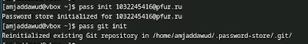

Инициализирование хранилище

## Установка и Настройка Pass

Перехожу в ~/.password-store для посмотра статуса синхронизации:

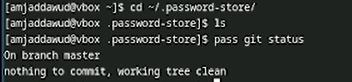

посмотр статуса синхронизации

## Настройка интерфейса с броузером

Добавляю плагин browserpass для firefox через броузера:

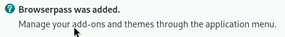

Добавлен плагин

## Настройка интерфейса с броузером

Для взаимодействия с броузером используется интерфейс native messaging. Поэтому кроме плагина к броузеру устанавливается программа, обеспечивающая интерфейс native messaging. Делаю это через терминала

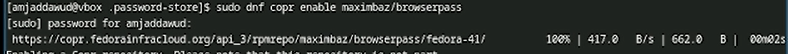

Включение репозитория Copr

## Настройка интерфейса с броузером

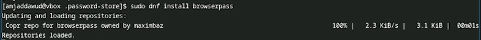

Установка browserpass native

## Сохранение пароля

Добавляю новый пароль в файле, который будет использоваться для хранения пароля. Этот файл находится в каталоге, определяющее файловую структуру для вашего хранилища паролей.

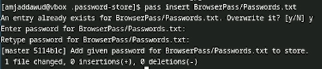

Добавление пароля

## Сохранение пароля

При запуске pass BrowserPass/Passwords.txt, выводится запрос подтвердить созданный пароль:

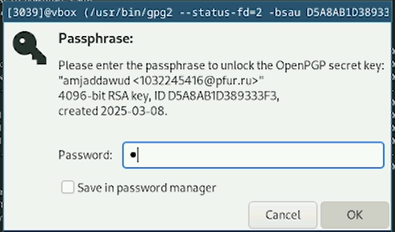

Подтверждение созданного пароля

## Сохранение пароля

Заменяю существующий пароль с помощью pass generate –in-place Passwords.txt

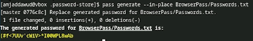

Замена пароля

## Дополнительное программное обеспечение

Устанавливаю дополнительное программное обеспечение:

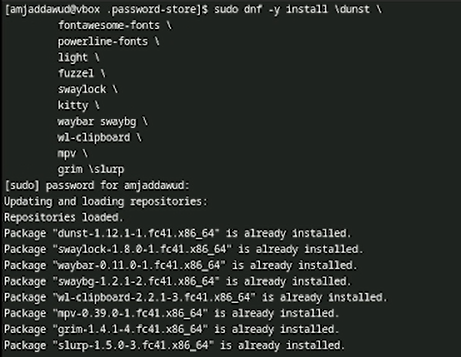

Установка дополнительного программного обеспечения

## Дополнительное программное обеспечение

Установливаю шрифты iosevka. Для этого надо включть copr peterwu/iosevka и искать iosevka:

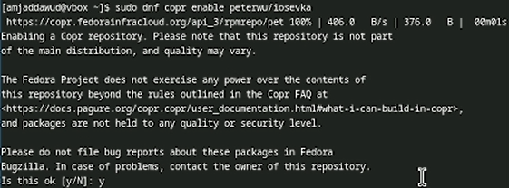

Включение copr peterwu/iosevka

## Дополнительное программное обеспечение

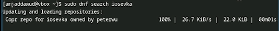

Поиск iosevka

## Дополнительное программное обеспечение

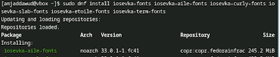

Установка шрифты

## Установка бинарного файла

Скрипт определяет архитектуру процессора и операционную систему и скачивает необходимый файл, поэтому я просто запускаю sh -c “$(wget -qO- chezmoi.io/get)”:

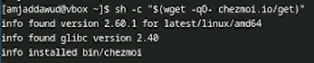

Установка chezmoi

## Создание собственного репозитория

С помощью утилита gh я создаю новый репозиторий dotfiles по шаблону yamadharma

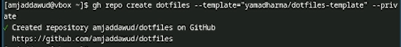

Создание репозиторий

## Подключение репозитория к своей системе

Сhezmoi является клоном репозитория dotfiles. Инициализирую его:

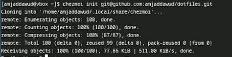

Инициализирование Сhezmoi

## Подключение репозитория к своей системе

Проверяю какие изменения внесёт chezmoi в домашний каталог, запуская chezmoi diff:

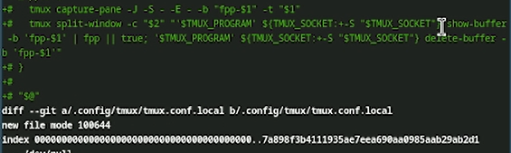

Проверка изменений

## Подключение репозитория к своей системе

Применяю изменения запускав chezmoi apply -v:

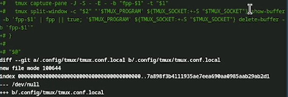

Применение изменений

## Использование chezmoi на нескольких машинах

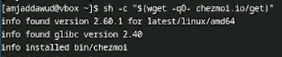

## Использование chezmoi на нескольких машинах

Проверяю какие изменения внесёт chezmoi в домашний каталог, запуская chezmoi diff:

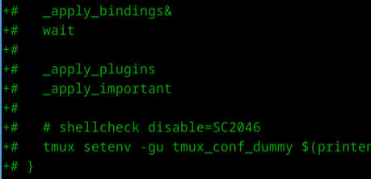

Проверка изменений на второй машине

## Использование chezmoi на нескольких машинах

Применяю изменения запускав chezmoi apply -v:

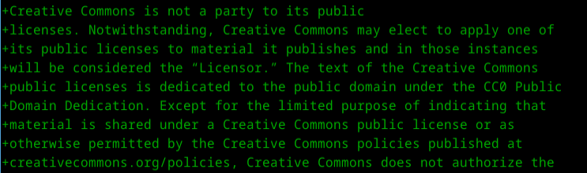

Применение изменений на второй машине

## Ежедневные операции c chezmoi

Выполняю chezmoi git pull – –autostash –rebase && chezmoi diff. Это запускается git pull –autostash –rebase в исходном каталоге, а chezmoi diff затем показывает разницу между целевым состоянием, вычисленным из исходного каталога, и фактическим состоянием.

## Ежедневные операции c chezmoi

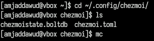

## Ежедневные операции c chezmoi

Когда в исходный каталог вносятся изменения, chezmoi фиксирует изменения с помощью автоматически сгенерированного сообщения фиксации и отправляет их в репозиторий. Эта функция отключена по умолчанию но у меня уже была включено. Можно это увидеть в файле конфигурации ~/.config/chezmoi/chezmoi.toml:

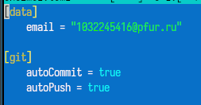

Функция фиксирование изменений автоматически